# Getting started with R

This notebook contains the answers to Task 1: Get started with R.

This notebook is intended to learn the basics of R.

```r
library(readr)
```

```r
df_car<- read.csv("../cars.csv")
```

*Understand the data:*

```r
print("List your attributes within your data set.")
```

```
[1] "List your attributes within your data set."
```

```r
attributes(df_car)
```

```
$names
[1] "name.of.car"     "speed.of.car"    "distance.of.car"

$class
[1] "data.frame"

$row.names
 [1]  1  2  3  4  5  6  7  8  9 10 11 12 13 14 15 16 17 18 19
[20] 20 21 22 23 24 25 26 27 28 29 30 31 32 33 34 35 36 37 38
[39] 39 40 41 42 43 44 45 46 47 48 49 50
```

```r
print("Prints the min, max, mean, median, and quartiles of each attribute.")
```

```
[1] "Prints the min, max, mean, median, and quartiles of each attribute."
```

```r
summary(df_car)
```

```
 name.of.car         speed.of.car  distance.of.car
 Length:50          Min.   : 4.0   Min.   :  2.00
 Class :character   1st Qu.:12.0   1st Qu.: 26.00
 Mode  :character   Median :15.0   Median : 36.00
                    Mean   :15.4   Mean   : 42.98
                    3rd Qu.:19.0   3rd Qu.: 56.00
                    Max.   :25.0   Max.   :120.00
```

```r
print("Displays the structure of your data set.")
```

```
[1] "Displays the structure of your data set."
```

```r
str(df_car)
```

```
'data.frame':   50 obs. of  3 variables:
 $ name.of.car    : chr  "Ford" "Jeep" "Honda" "KIA" ...
 $ speed.of.car   : int  4 4 7 7 8 9 10 10 10 11 ...
 $ distance.of.car: int  2 4 10 10 14 16 17 18 20 20 ...
```

```r
print("Names your attributes within your data set.")
```

```
[1] "Names your attributes within your data set."
```

```r
names(df_car)
```

```
[1] "name.of.car"     "speed.of.car"    "distance.of.car"
```

```r
print("Will print out the instances within that particular column in your data set.")
```

```
[1] "Will print out the instances within that particular column in your data set."
```

```r
df_car$speed.of.car #
```

```
 [1]  4  4  7  7  8  9 10 10 10 11 11 12 12 12 12 13 13 13 13
[20] 14 14 14 14 15 15 15 16 16 17 17 17 18 18 18 18 19 19 19
[39] 20 20 20 20 20 22 23 24 24 24 24 25
```

```r
df_car$distance.of.car #Will print out the instances within that particular column in your data set.
```

```
 [1]   2   4  10  10  14  16  17  18  20  20  22  24  26  26
[15]  26  26  28  28  32  32  32  34  34  34  36  36  40  40
[29]  42  46  46  48  50  52  54  54  56  56  60  64  66  68
[43]  70  76  80  84  85  92  93 120
```

```r
sapply(df_car, typeof)
```

```
    name.of.car    speed.of.car distance.of.car
    "character"       "integer"       "integer"
```

```r
#df_car$ColumnName<-integer(df_car$ColumnName)
```

```r
names(df_car)<-c("CarMaker","Speed","Dist")
```

```r
summary(df_car)
```

```
   CarMaker             Speed           Dist
 Length:50          Min.   : 4.0   Min.   :  2.00
 Class :character   1st Qu.:12.0   1st Qu.: 26.00
 Mode  :character   Median :15.0   Median : 36.00
                    Mean   :15.4   Mean   : 42.98
                    3rd Qu.:19.0   3rd Qu.: 56.00
                    Max.   :25.0   Max.   :120.00
```

```r
any(is.na(df_car))
```

```
[1] FALSE
```

There are no missing values in the car_df, thus the chunk below is unnecessary.

```r
#na.omit(DatasetName$ColumnName#Drops any rows with missing values and omits them forever.
#na.exclude(DatasetName$ColumnName)#Drops any rows with missing values, but keeps track of where they were.
#DatasetName$ColumnName[is.na(DatasetName$ColumnName)]<-mean(DatasetName$ColumnName,na.rm = TRUE) #Replace the missing values with the mean
```

*Exploratory Data Analysis*

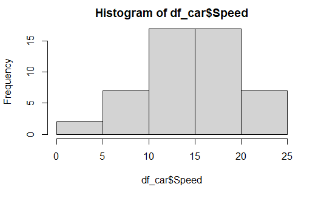

```r
hist(df_car$Speed)
```

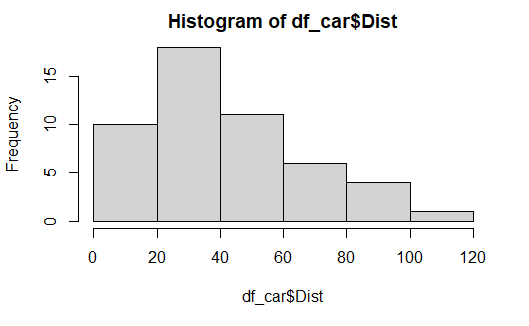

```r
hist(df_car$Dist)
```

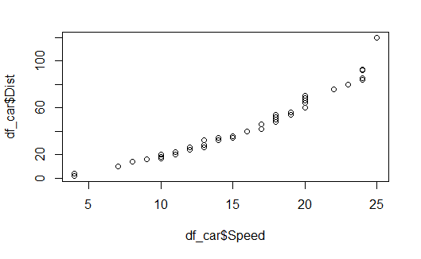

```r
plot(df_car$Speed,df_car$Dist)
```

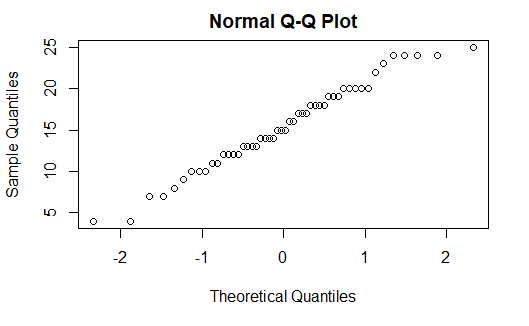

```r
qqnorm(df_car$Speed)
```

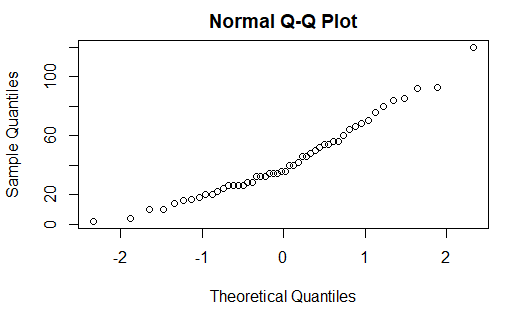

```r
qqnorm(df_car$Dist)
```

As can be seen above, the relationship between distance and speed is pretty close to a line, thus a linear regression will probably yield good results when modelling one of these variables.

*Creating testing and training sets:*

```r
set.seed(42)

trainSize<-round(nrow(df_car)*0.7) #70% for train dataset
testSize<-nrow(df_car)-trainSize #Remaining 30% for test dataset


trainSize
```

```
[1] 35
```

```r
testSize
```

```
[1] 15
```

```r
training_indices<-sample(seq_len(nrow(df_car)),size =trainSize) # Select random sample of row numbers with size 'trainsize'

trainSet<-df_car[training_indices,] #TrainSet will contain the selected indices.

testSet<-df_car[-training_indices,] #TestSet will contain only the remaining rows that have not been selected.
```

*Linear Regression Model*

```r
DistModel<-lm(Dist ~ Speed-1, trainSet) # response(y) ~ terms(X)
# used -1 to omit intercept
summary(DistModel)
```

```
Call:
lm(formula = Dist ~ Speed - 1, data = trainSet)

Residuals:
    Min      1Q  Median      3Q     Max
-13.904 -11.363  -9.315  -0.103  42.945

Coefficients:
      Estimate Std. Error t value Pr(>|t|)
Speed   3.0822     0.1302   23.68   <2e-16 ***
---
Signif. codes:  0 ‘***’ 0.001 ‘**’ 0.01 ‘*’ 0.05 ‘.’ 0.1 ‘ ’ 1

Residual standard error: 12.8 on 34 degrees of freedom
Multiple R-squared:  0.9428,    Adjusted R-squared:  0.9411
F-statistic: 560.5 on 1 and 34 DF,  p-value: < 2.2e-16
```

The multiple R-squared is 0.943 which is preety close to 1, this models seems to be a good fit.

The p-value is clearly smaller than 0.05 meaning that the relationship between these two variables is statistically significant.

Adjusted R-squared is used to determine how reliable the correlation is and how much it is determined by the addition of independent variables.

F-statistics are based on the ratio of mean squares. The term “mean squares” may sound confusing but it is simply an estimate of population variance that accounts for the degrees of freedom (DF) used to calculate that estimate.

```r
DistPredictions <- predict(DistModel,testSet)
cbind(Pred_Dist = DistPredictions,Real_Dist = testSet$Dist)
```

```
   Pred_Dist Real_Dist
6   27.73984        16
9   30.82205        20
14  36.98645        26
16  40.06866        26
17  40.06866        28
19  40.06866        32
21  43.15086        32
22  43.15086        34
23  43.15086        34
29  52.39748        42
33  55.47968        50
35  55.47968        54
39  61.64409        60
42  61.64409        68
43  61.64409        70
```